# numpy第三段

```python
%%HTML
<style type='text/css'>
    *{
        # background-color:#E3EDCD;
        # background-color:black;
        # color:white;

    }
    h1{
        color:#1976d2;
    }
    h2{
        color:#f57c00;
    }
    h3{
        color:#ba37ff;
    }
    table{
        border:1px solid black !important;
        border-collapse:collapse !important;
    }
    th{
        background-color:blueviolet !important;
        text-align:center;
        color:white;
    }
    th,td{
        border:0.1px solid black !important;
        transition:0.2s all liner;

    }
    td:hover{
        transform:scale(1.1);
        background-color:orange;
        color:blueviolet;
    }
    .raw{
        white-space:pre;
    }
</style>
```

## 2.8数组的排序

```python
import numpy as np
def selection_sort(x):
    for i in range(len(x)):
        swap = i + np.argmin(x[i:]) #设置要换位置的索引号
        (x[i],x[swap]) = (x[swap],x[i]) #实现交换
        return x
```

```python
x = np.array([2,1,4,3,5])
# 调用函数
selection_sort(x)
```

```
array([1, 2, 4, 3, 5])
```

[figure not shown]

注意上文中的argmin(x[i:])这种每次i的值都不一样，所以每次都会形成一个新的数组

```python
np.argmin? #我们查看一下np.argmin的使用方法
```

[output not shown]

[output cut: 60 more lines]

[output not shown]

正如任何大学一年级的计算机科学课程会告诉你的，选择排序因为其简 洁而非常有用，但是它对于大数组来说太慢了。对于一个包含 N 个值的 数组来说，它需要做 N 个循环，每个循环中执行~ N 次比较，以找到交 换值。“大 O 标记”常用来标示算法的复杂度（详情请参见 2.8.3 节）， 选择排序的平均算法复杂度为 [N<sup>2</sup>]：如果你将列表中元素的个数翻 倍，那么运行时间就会延长 4 倍。

Python 包含的很多内置排序算法都比上面例子中的算法高效 得多。首先介绍 Python 的内置排序算法，然后介绍 NumPy 中的排序算 法和优化过的 NumPy 数组排序算法。

### 2.8.1 NumPy中的快速排序：np.sort和np.argsort

尽管 Python 有内置的 sort 和 sorted 函数可以对列表进行排序，但是 这里不会介绍这两个函数，因为 NumPy 的 np.sort 函数实际上效率更 高。默认情况下，np.sort 的排序算法是 快速排序，其算法复杂度为O [N log N]，另外也可以选择归并排序和堆排序。对于大多数应用场 景，默认的快速排序已经足够高效了。

如果想在不修改原始输入数组的基础上返回一个排好序的数组，可以使 用 np.sort：

```python
x=np.array([2,1,4,3,5])
np.sort(x)
```

```
array([1, 2, 3, 4, 5])
```

如果希望用排好序的数组替代原始数组，可以使用数组的 sort 方法：

```python
x.sort()
print(x)
```

```
[1 2 3 4 5]
```

另外一个相关的函数是 argsort，该函数返回的是原始数组排好序的索 引值：

```python
x = np.array([2,1,4,3,5])
i = np.argsort(x)
x
```

```
array([2, 1, 4, 3, 5])
```

```python
i #可以看到原数组没有发生变化,但是i已经是排序好后的数组x的索引数组
```

```
array([1, 0, 3, 2, 4])
```

以上结果的第一个元素是数组中最小元素的索引值，第二个值给出的是 次小元素的索引值，以此类推。这些索引值可以被用于（通过花哨的索 引）创建有序的数组：

```python
# 得到排序后的数组
x[i]
```

```
array([1, 2, 3, 4, 5])
```

沿着行或列排序

NumPy 排序算法的一个有用的功能是通过 axis 参数，沿着多维数组的 行或列进行排序，例如：

```python
rand = np.random.RandomState(42)
X = rand.randint(0,10,(4,6))
X
```

```
array([[6, 3, 7, 4, 6, 9],
       [2, 6, 7, 4, 3, 7],
       [7, 2, 5, 4, 1, 7],
       [5, 1, 4, 0, 9, 5]], dtype=int32)
```

```python
# 对X的每一列排序
np.sort(X,axis=0)
```

```
array([[2, 1, 4, 0, 1, 5],
       [5, 2, 5, 4, 3, 7],
       [6, 3, 7, 4, 6, 7],
       [7, 6, 7, 4, 9, 9]], dtype=int32)
```

```python
# 对每一行进行排序
np.sort(X,axis=1)
```

```
array([[3, 4, 6, 6, 7, 9],
       [2, 3, 4, 6, 7, 7],
       [1, 2, 4, 5, 7, 7],
       [0, 1, 4, 5, 5, 9]], dtype=int32)
```

需要记住的是，这种处理方式是将行或列当作独立的数组，任何行或列 的值之间的关系将会丢失！

### 2.8.2 部分排序：分隔

有时候我们不希望对整个数组进行排序，仅仅希望找到数组中第 K 小的 值，NumPy 的 np.partition 函数提供了该功能。np.partition 函 数的输入是数组和数字 K，输出结果是一个新数组，最左边是第 K 小的 值，往右是任意顺序的其他值：

```python
x = np.array([7,2,3,1,6,5,4])
np.partition(x,3)
```

```
array([1, 2, 3, 4, 5, 6, 7])
```

请注意，结果数组中前三个值是数组中最小的三个值，剩下的位置是原 始数组剩下的值。在这两个分隔区间中，元素都是任意排列的。

与排序类似，也可以沿着多维数组任意的轴进行分隔：

```python
np.partition(X,2,axis=1)
#按照行排序设定kth的值为2，
# 即最左边的俩一定是整个数组里的第一第二小的值无序后面的不变
```

[output not shown]

输出结果是一个数组，该数组每一行的前两个元素是该行最小的两个 值，每行的其他值分布在剩下的位置。

最后，正如 np.argsort 函数计算的是排序的索引值，也有一个 np.argpartition 函数计算的是分隔的索引值，我们将在下一节中举 例介绍它。

### 2.8.3 示例：K个最近邻

以下示例展示的是如何利用 argsort 函数沿着多个轴快速找到集合中 每个点的最近邻。首先，在二维平面上创建一个有 10 个随机点的集 合。按照惯例，将这些数据点放在一个 10×2 的数组中：

```python
X = rand.rand(10,2)
```

```python
X
```

```
array([[0.00706631, 0.02306243],
       [0.52477466, 0.39986097],
       [0.04666566, 0.97375552],
       [0.23277134, 0.09060643],
       [0.61838601, 0.38246199],
       [0.98323089, 0.46676289],
       [0.85994041, 0.68030754],
       [0.45049925, 0.01326496],
       [0.94220176, 0.56328822],
       [0.3854165 , 0.01596625]])
```

为了对这些点有一个直观的印象，来画出它的散点图（如图 2-10 所 示）：

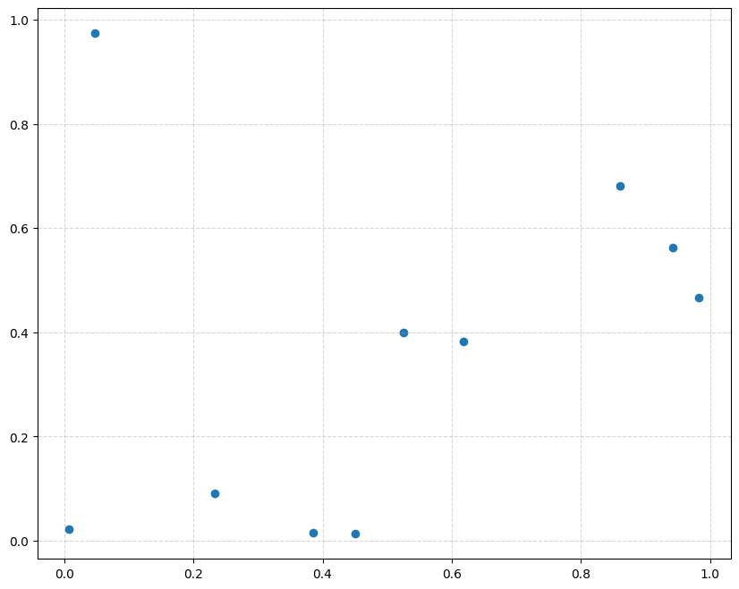

```python
import matplotlib.pyplot as plt
plt.figure(figsize=(10,8),dpi=100)
plt.grid(True,linestyle='--',alpha=0.5)
plt.scatter(X[:,0],X[:,1])
plt.show()
```

图 2-10：将示例 k 个最近邻中的点可视化

现在来计算两两数据点对间的距离。我们学过两点间距离的平方等于每 个维度的距离差的平方的和。利用 NumPy 的广播（详情请参见 2.5 节）和聚合（详情请参见 2.4 节）功能，可以用一行代码计算矩阵的平 方距离：

```python
dist_sq = np.sum((X[:,np.newaxis,:] - X[np.newaxis,:,:]) ** 2, axis=-1)
```

这个操作由很多部分组成。如果你对 NumPy 的广播规则不熟悉的话， 可能这行代码看起来有些令人困惑。当你遇到这种代码时，将其各组件 分解后再分析是非常有用的：

```python
# # 在坐标系中计算每对点的差值
differences = X[:,np.newaxis,:] - X[np.newaxis,:,:]
differences.shape
```

```
(10, 10, 2)
```

```python
differences
```

```
array([[[ 0.        ,  0.        ],
        [-0.51770836, -0.37679855],
        [-0.03959936, -0.95069309],
        [-0.22570504, -0.06754401],
        [-0.6113197 , -0.35939957],
        [-0.97616458, -0.44370047],
        [-0.8528741 , -0.65724511],
        [-0.44343295,  0.00979746],
        [-0.93513545, -0.54022579],
        [-0.3783502 ,  0.00709617]],

       [[ 0.51770836,  0.37679855],
        [ 0.        ,  0.        ],
        [ 0.478109  , -0.57389455],
        [ 0.29200332,  0.30925454],
        [-0.09361135,  0.01739898],
        [-0.45845623, -0.06690192],
        [-0.33516575, -0.28044657],
        [ 0.07427541,  0.38659601],
        [-0.4174271 , -0.16342725],
        [ 0.13935816,  0.38389472]],

       [[ 0.03959936,  0.95069309],
        [-0.478109  ,  0.57389455],
        [ 0.        ,  0.        ],
        [-0.18610568,  0.88314908],
        [-0.57172035,  0.59129353],
        [-0.93656522,  0.50699263],
        [-0.81327474,  0.29344798],
        [-0.40383359,  0.96049056],
        [-0.89553609,  0.4104673 ],
        [-0.33875084,  0.95778927]],

       [[ 0.22570504,  0.06754401],
        [-0.29200332, -0.30925454],
        [ 0.18610568, -0.88314908],
        [ 0.        ,  0.        ],
        [-0.38561467, -0.29185556],
        [-0.75045955, -0.37615646],
        [-0.62716907, -0.5897011 ],
```

[output cut: 54 more lines]

```
        [ 0.08226135, -0.11701932],
        [ 0.4917025 ,  0.55002326],
        [ 0.        ,  0.        ],
        [ 0.55678525,  0.54732197]],

       [[ 0.3783502 , -0.00709617],
        [-0.13935816, -0.38389472],
        [ 0.33875084, -0.95778927],
        [ 0.15264516, -0.07464018],
        [-0.23296951, -0.36649574],
        [-0.59781438, -0.45079664],
        [-0.4745239 , -0.66434129],
        [-0.06508275,  0.00270129],
        [-0.55678525, -0.54732197],
        [ 0.        ,  0.        ]]])
```

```python
# 求出差值的平方
sq_differences = differences ** 2
sq_differences.shape
```

```
(10, 10, 2)
```

```python
# 将差值求和获得平方距离
dist_sq = sq_differences.sum(-1)
dist_sq.shape
```

```
(10, 10)
```

请再次确认以上步骤，应该看到该矩阵的对角线（也就是每个点到其自 身的距离）的值都是 0：

```python
dist_sq.diagonal()
```

```
array([0., 0., 0., 0., 0., 0., 0., 0., 0., 0.])
```

结果确实是这样的！当我们有了这样一个转化为两点间的平方距离的矩 阵后，就可以使用 np.argsort 函数沿着每行进行排序了。最左边的列 给出的索引值就是最近邻：

```python
nearest = np.argsort(dist_sq,axis=1)
print(nearest)
```

```
[[0 3 9 7 1 4 2 5 6 8]
 [1 4 7 9 3 6 8 5 0 2]
 [2 1 4 6 3 0 8 9 7 5]
 [3 9 7 0 1 4 5 8 6 2]
 [4 1 8 5 6 7 9 3 0 2]
 [5 8 6 4 1 7 9 3 2 0]
 [6 8 5 4 1 7 9 3 2 0]
 [7 9 3 1 4 0 5 8 6 2]
 [8 5 6 4 1 7 9 3 2 0]
 [9 7 3 0 1 4 5 8 6 2]]
```

需要注意的是，第一列是按 0~9 从小到大排列的。这是因为每个点的最 近邻是其自身，所以结果也正如我们所想。

如果使用全排序，我们实际上可以实现的比这个例子展示的更多。如果 我们仅仅关心 k 个最近邻，那么唯一需要做的是分隔每一行，这样最小 的 k + 1 的平方距离将排在最前面，其他更长的距离占据矩阵该行的其 他位置。可以用 np.argpartition 函数实现：

```python
K = 2
nearest_partition = np.argpartition(dist_sq, K + 1, axis=1)
```

为了将邻节点网络可视化，我们将每个点和其最近的两个最近邻连接 （如图 2-11 所示）：

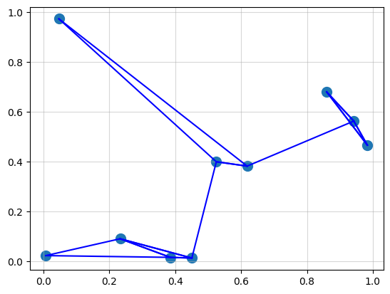

```python
plt.scatter(X[:,0],X[:,-1],s=100)
plt.grid(True,alpha=0.5)
# 将每个点与它的两个最近邻连接

K=2
for i in range(X.shape[0]):
    for j in nearest_partition[i,:K+1]:
        # 画一条从X[i]到x[j]的线段
        # 用zip方法实现
        plt.plot(*zip(X[j],X[i]),color='b') #注意这里用到了解包赋值
        # 因为传入的是可变位置参数是个元组解包元组需要在其前面加上单*号
# plt.show()
```

图 2-11：每个点的邻节点的可视化

图中每个点和离它最近的两个节点用连线连接。乍一看，你可能会奇怪 为什么有些点的连线多于两条，这是因为点 A 是点 B 最邻近的两个节 点之一，但是并不意味着点 B 一定是点 A 的最邻近的两个节点之一。 尽管本例中的广播和按行排序可能看起来不如循环直观，但是在实际运 行中，Python 中这类数据的操作会更高效。你可能会尝试通过手动循环 数据并对每一组邻节点单独进行排序来实现同样的功能，但是这种方法 和我们使用的向量化操作相比，肯定在算法执行上效率更低。并且向量 化操作的优美之处在于，它的实现方式决定了它对输入数据的数据量并 不敏感。也就是说，我们可以非常轻松地计算任意维度空间的 100 或 1 000 000 个邻节点，而代码看起来是一样的。 最后还想提醒一点，做大数据量的最近邻搜索时，有几种基于树的算法 的算法复杂度可以实现接近 O[N log N ]，或者比暴力搜索法的 O[N<sup>2</sup> ] 更好。其中一种就是 KD-Tree，在 Scikit-Learn中实现。

大 O 标记 大 O 标记是一种描述一个算法对于相应的输入数据的大小需要执 行的操作步骤数。要想正确使用它，需要深入理解计算机科学理 论，并且将其和小 o 标记、大 θ 标记、大 Ω 标记以及其他混合变 体区分开。虽然区分这些概念可以提高算法复杂度计量的准确性， 但是除了在计算机科学理论和学究的博客评论外，实际中很少有这 种区分。在数据科学中，更常见的还是不太严谨的大 O 标记—— 一种通用的（或许是不准确的）算法复杂度的度量描述。在这里要 向相关的理论学家和学者致歉，本书中都会使用这种表述方式。 如果不用太严谨的眼光看待大 O 标记，那么它其实是告诉你：随 着输入数据量的增长，你的算法将花费多少时间。如果你有一个 [N]（读作“N 阶”）复杂度的算法，该算法花费 1 秒钟来执行一个长 度为 N = 1000 的列表，那么它执行一个长度为 N = 5000 的列表花 费的时间大约是 5 秒钟。如果你有一个算法复杂度为 O[N<sup>2</sup>]（读 作“N 的平方阶”），且该算法花费 1 秒钟来执行一个长度为 N = 1000 的列表，那么它执行一个长度为 N = 5000 的列表花费的时间 大约是 25 秒钟。 在计算算法复杂度时，N 通常表示数据集的大小（数据点的个数、 维度的数目等）。当我们试图分析数十亿或数百万亿的数据时，算 法复杂度为 O[N] 和算法复杂度为 O[N<sup>2</sup>] 会有非常明显的差别！ 需要注意的是，大 O 标记并没有告诉你计算的实际时间，而仅仅 告诉你改变 N 的值时，运行时间的相应变化。通常情况下， O[N] 复杂度的算法比 O[N<sup>2</sup>] 复杂度的算法更高效。但是对于小数据集， 算法复杂度更优的算法可能未必更快。例如对于给定的问题，O [N<sup>2</sup>] 复杂度的算法可能会花费 0.01 秒，而更“优异”的O [N] 复杂度的 算法可能会花费 1 秒。按照 1000 的因子将 N 倍增，那么 O[N] 复杂 度的算法将胜出。 即使是这个非严格版本的大 O 标记对于比较算法的性能也是非常 有用的。我们将在本书中用这个标记来测量算法复杂度。

## 2.9 结构化数据：NumPy的结构化数组

```python
name = ['Alice', 'Bob', 'Cathy', 'Doug']
age = [25, 45, 37, 19]
weight = [55.0, 85.5, 68.0, 61.5]
```

但是这种方法有点笨，因为并没有任何信息告诉我们这三个数组是相关 联的。如果可以用一种单一结构来存储所有的数据，那么看起来会更自 然。NumPy 可以用结构化数组实现这种存储，这些结构化数组是复合 数据类型的。

前面介绍过，利用以下表达式可以生成一个简单的数组：

x = np.zeros(4, dtype=int)

与之类似，通过指定复合数据类型，可以构造一个结构化数组：

```python
# 使用复合数据结构的结构化数组
data = np.zeros(4,dtype={'names':('name','age','weight'),
                        'formats':('U10','i4','f8')})
print(data.dtype)
```

```
[('name', '<U10'), ('age', '<i4'), ('weight', '<f8')]
```

这里 U10 表示“长度不超过 10 的 Unicode 字符串”，i4 表示“4 字节（即 32 比特）整型”，f8 表示“8 字节（即 64 比特）浮点型”。后续的小节中 将介绍更多的数据类型代码。

现在生成了一个空的数组容器，可以将列表数据放入数组中：

```python
data['name']=name
data['age'] = age
data['weight'] = weight
print(data)
```

```
[('Alice', 25, 55. ) ('Bob', 45, 85.5) ('Cathy', 37, 68. )
 ('Doug', 19, 61.5)]
```

正如我们希望的，所有的数据被安排在一个内存块中。 结构化数组的方便之处在于，你可以通过索引或名称查看相应的值：

```python
# 获取所有的名字
data['name']
```

```
array(['Alice', 'Bob', 'Cathy', 'Doug'], dtype='<U10')
```

```python
# 获取数据第一行
data[0]
```

```
np.void(('Alice', 25, 55.0), dtype=[('name', '<U10'), ('age', '<i4'), ('weight', '<f8')])
```

```python
# 获取最后一行的名字
data[-1]['name']
```

```
np.str_('Doug')
```

利用布尔掩码，还可以做一些更复杂的操作，如按照年龄进行筛选：

```python
# 获取年龄小于30岁的人的名字
data[data['age'] < 30]['name']
```

```
array(['Alice', 'Doug'], dtype='<U10')
```

请注意，如果你希望实现比上面更复杂的操作，那么你应该考虑使用 Pandas 包，我们将在下一章中详细介绍它。正如你将会看到的，Pandas 提供了一个 DataFrame 对象，该结构是构建于 NumPy 数组之上的，提 供了很多有用的数据操作功能，其中有些与前面介绍的类似，当然也有 更多没提过并且非常实用的功能

```python
# 之后的内容不再继续写下去，因为就像你用手算乘法,当然是一件好事,
# 可是你不能说别人用计算机算就是坏事,不再写下去的原因作者写的也很明确了,pandas更牛
# 所以转下一章pandas
```